# Applied Regression Analysis & Generalized Linear Models

Author

Rick Dean

Abstract

Notes and graphics from the book [Applied Regression Analysis and Generalized Linear Models](https://www.john-fox.ca/AppliedRegression/index.html) by John Fox. The following R script is following Chapter 3 ‘Examining Data’

Load the Required R Packages:

```r
library(data.table)
library(ggplot2)
library(ggrepel)
library(here)
library(gt)
library(magrittr)
library(RplotterPkg)
library(RregressPkg)
```

# 3 Examining Data

## 3.1 Univariate Displays

### 3.1.1 Histograms

Read and show the histogram of infant mortality rates

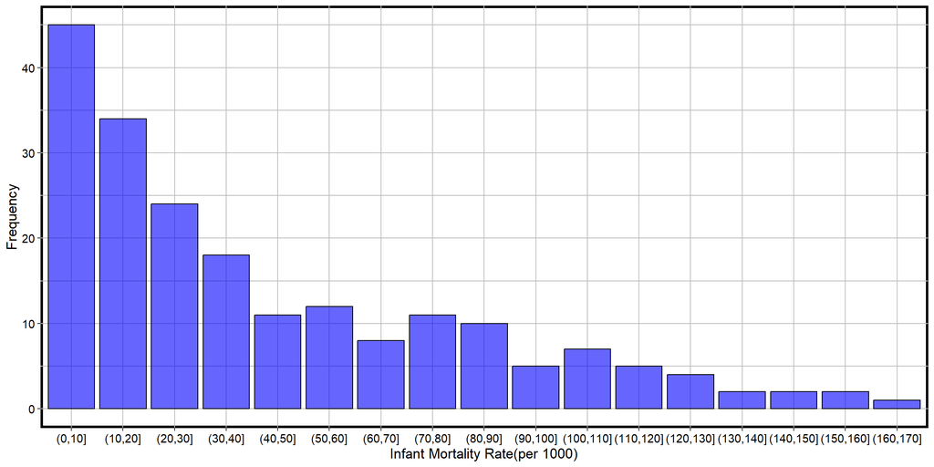

Histogram of United Nations infant mortality data

```r
data_path <- file.path(here(),
  "books",
  "Applied Regression Analysis and Generalized Linear Models",
  "data",
  "UnitedNations.txt"
)
un_dt <- data.table::fread(data_path) %>%
  .[, .(country, infantMortality)] %>%
  na.omit(.)

infantMortality_levels <- seq(0,170,by=10)

RplotterPkg::create_bar_plot(
  df = un_dt,
  aes_x = "infantMortality",
  x_major_breaks = infantMortality_levels,
  bar_fill = "blue",
  bar_alpha = 0.6,
  x_title = "Infant Mortality Rate(per 1000)",
  y_title = "Frequency",
  rot_y_tic_label = T
)
```

Show a stem and leaf disply of the United Nations infant mortality data.

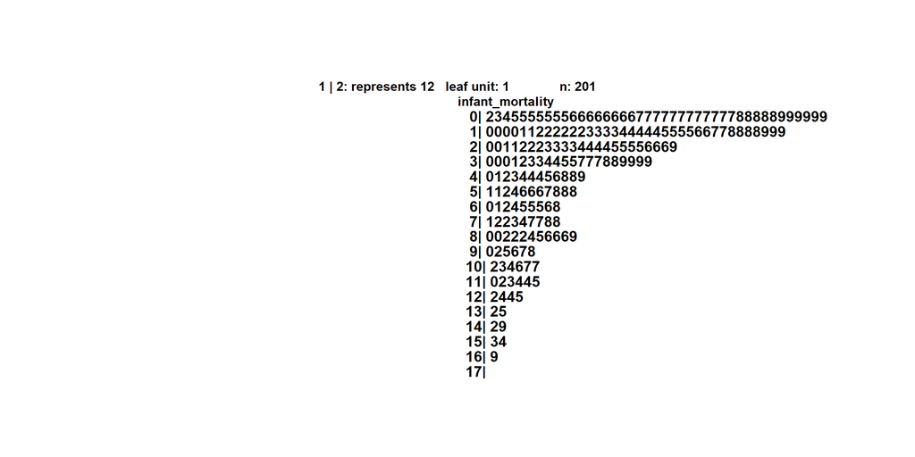

Stem and leaf disply of the United Nations infant mortality data

```r
RplotterPkg::stem_leaf_display(
  x = list("infant_mortality" = un_dt$infantMortality),
  col_width = 20,
  font_sz = 14
)
```

### 3.1.2 Nonparametric Density Estimation

Plot the nonparametric density estimation of infant mortality rates using a naive or uniform kernal.

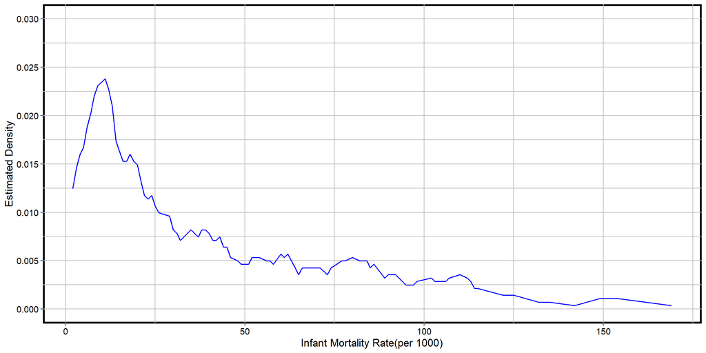

Nonparametric density estimation of infant mortality rates using a naive or uniform kernal

```r
uniform_kernal_fun <- function(z){
  ifelse(abs(z) < 1, 0.5, 0)
}

h <- 7
n <- nrow(un_dt)
nh <- n * h
prob_v <- rep(0, n)

data.table::setorderv(un_dt, cols = "infantMortality")

for(i in 1:n){
  x0 <- un_dt$infantMortality[i]
 z_v <- (un_dt$infantMortality - x0)/h
 kernal_v <- uniform_kernal_fun(z_v)
 prob_v[[i]] <- sum(kernal_v)/nh
}

prob_df <- data.frame(
  x = un_dt$infantMortality,
  y = prob_v
)

RplotterPkg::create_scatter_plot(
  df = prob_df,
  aes_x = "x",
  aes_y = "y",
  x_title = "Infant Mortality Rate(per 1000)",
  y_title = "Estimated Density",
  # x_limits = c(0, 30000),
  # x_major_breaks = seq(0,30000,5000),
  y_limits = c(0, 0.030),
  y_major_breaks = seq(0,0.030,0.005),
  show_pts = F,
  connect = T,
  rot_y_tic_label = T,
  line_color = "blue"
)
```

Plot the nonparametric density estimation of infant mortality rates using a normal density function kernal.

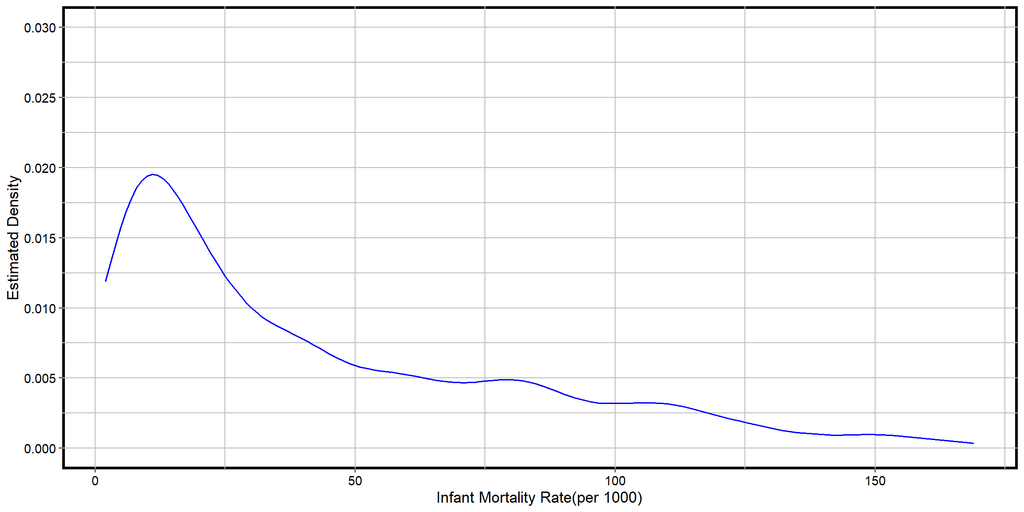

Nonparametric density estimation of infant mortality rates using a normal kernal

```r
normal_kernal_fun <- function(z){
  con_pi <- (2 * pi)^-0.5
  return(con_pi * exp(-0.5 * z^2))
}

h <- 7
n <- nrow(un_dt)
nh <- n * h
prob_v <- rep(0, n)

for(i in 1:n){
  x0 <- un_dt$infantMortality[i]
  z_v <- (un_dt$infantMortality - x0)/h
  kernal_v <- normal_kernal_fun(z_v)
  prob_v[[i]] <- sum(kernal_v)/nh
}

prob_df <- data.frame(
  x = un_dt$infantMortality,
  y = prob_v
)

RplotterPkg::create_scatter_plot(
  df = prob_df,
  aes_x = "x",
  aes_y = "y",
  x_title = "Infant Mortality Rate(per 1000)",
  y_title = "Estimated Density",
  # x_limits = c(0, 30000),
  # x_major_breaks = seq(0,30000,5000),
  y_limits = c(0, 0.030),
  y_major_breaks = seq(0,0.030,0.005),
  show_pts = F,
  connect = T,
  rot_y_tic_label = T,
  line_color = "blue"
)
```

Plot the nonparametric density estimation of infant mortality rates using a Epanechnikov kernel.

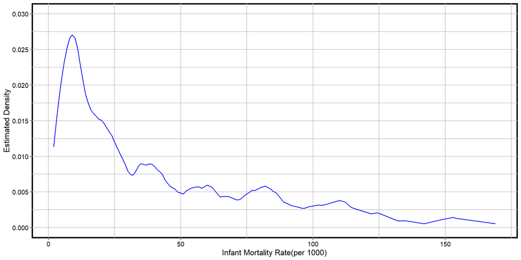

Nonparametric density estimation of infant mortality rates using a Epanechnikov kernal

```r
e_kernal_fun <- function(z){
  ifelse(abs(z) <= 1, 0.75 * (1 - z^2), 0)
}

h <- 7
n <- nrow(un_dt)
nh <- n * h
prob_v <- rep(0, n)

for(i in 1:n){
  x0 <- un_dt$infantMortality[i]
  z_v <- (un_dt$infantMortality - x0)/h
  kernal_v <- e_kernal_fun(z_v)
  prob_v[[i]] <- sum(kernal_v)/nh
}

prob_df <- data.frame(
  x = un_dt$infantMortality,
  y = prob_v
)

RplotterPkg::create_scatter_plot(
  df = prob_df,
  aes_x = "x",
  aes_y = "y",
  x_title = "Infant Mortality Rate(per 1000)",
  y_title = "Estimated Density",
  # x_limits = c(0, 30000),
  # x_major_breaks = seq(0,30000,5000),
  y_limits = c(0, 0.030),
  y_major_breaks = seq(0,0.030,0.005),
  show_pts = F,
  connect = T,
  rot_y_tic_label = T,
  line_color = "blue"
)
```

Plot the nonparametric density estimation of infant mortality rates using a triangular kernel.

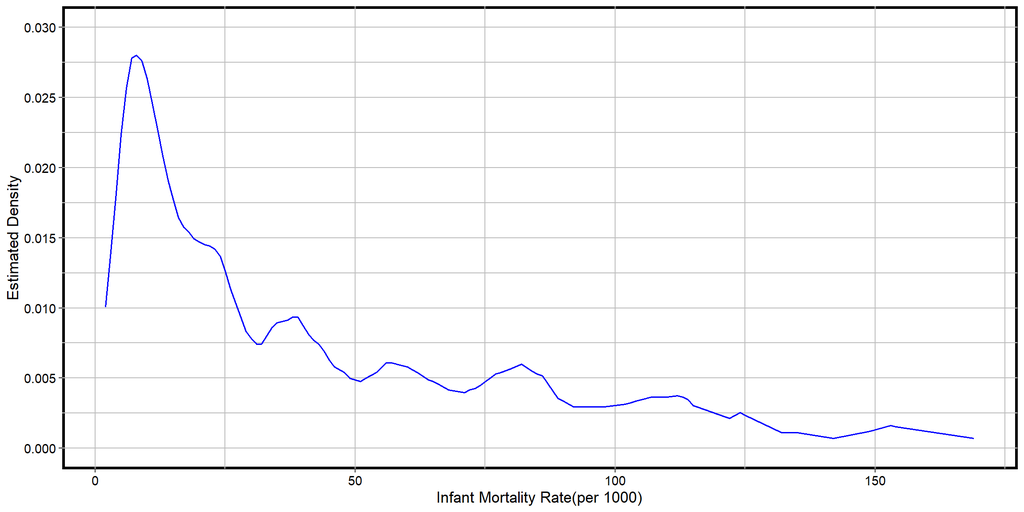

Nonparametric density estimation of infant mortality rates using a triangular kernal

```r
tri_kernal_fun <- function(z){
  ifelse(abs(z) <= 1, 1 - abs(z), 0)
}

h <- 7
n <- nrow(un_dt)
nh <- n * h
prob_v <- rep(0, n)

for(i in 1:n){
  x0 <- un_dt$infantMortality[i]
  z_v <- (un_dt$infantMortality - x0)/h
  kernal_v <- tri_kernal_fun(z_v)
  prob_v[[i]] <- sum(kernal_v)/nh
}

prob_df <- data.frame(
  x = un_dt$infantMortality,
  y = prob_v
)

RplotterPkg::create_scatter_plot(
  df = prob_df,
  aes_x = "x",
  aes_y = "y",
  x_title = "Infant Mortality Rate(per 1000)",
  y_title = "Estimated Density",
  # x_limits = c(0, 30000),
  # x_major_breaks = seq(0,30000,5000),
  y_limits = c(0, 0.030),
  y_major_breaks = seq(0,0.030,0.005),
  show_pts = F,
  connect = T,
  rot_y_tic_label = T,
  line_color = "blue"
)
```

### 3.1.3 Quantile-Comparison Plots

Display a normal quantile-comparison plot for a sample of 100 drawn from a normal population with mean 50 and standard deviation of 10.

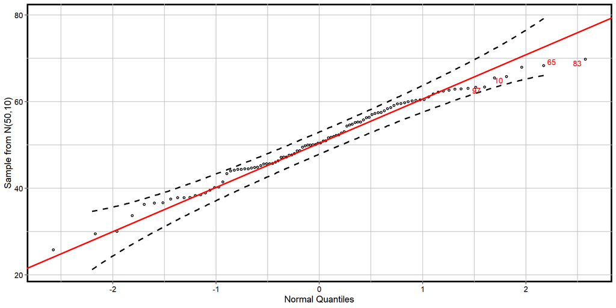

Normal quantile-comparison plot for a sample of 100

```r
set.seed(23)
data_df <- data.frame(
  idx = 1:100,
  values = rnorm(n = 100, mean = 50, sd = 10)
)
RregressPkg::plot_qq(
  df = data_df,
  numeric_col = "values",
  id_col = "idx",
  labels_n = 4,
  plot_ci_lines = T,
  ci_line_type = "dashed",
  x_title = "Normal Quantiles",
  y_title = "Sample from N(50,10)",
  rot_y_tic_label = T
)
```

### 3.1.4 Boxplots

Display a boxplot of the infant mortality data.

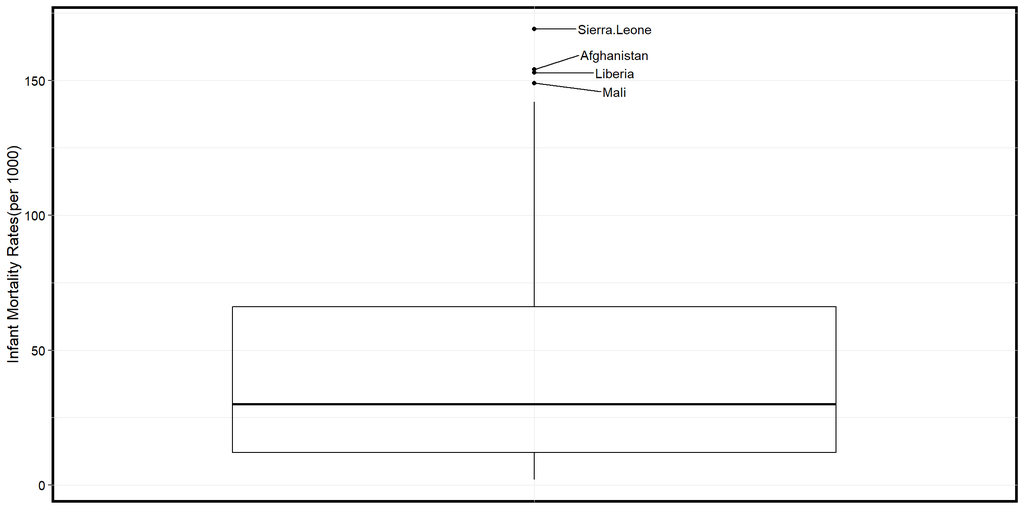

```r
RplotterPkg::create_box_plot(
  df = un_dt,
  aes_y = "infantMortality",
  aes_label = "country",
  y_title = "Infant Mortality Rates(per 1000)"
)
```

## 3.2 Plotting Bivariate Data

Display a parallel set of boxplots.

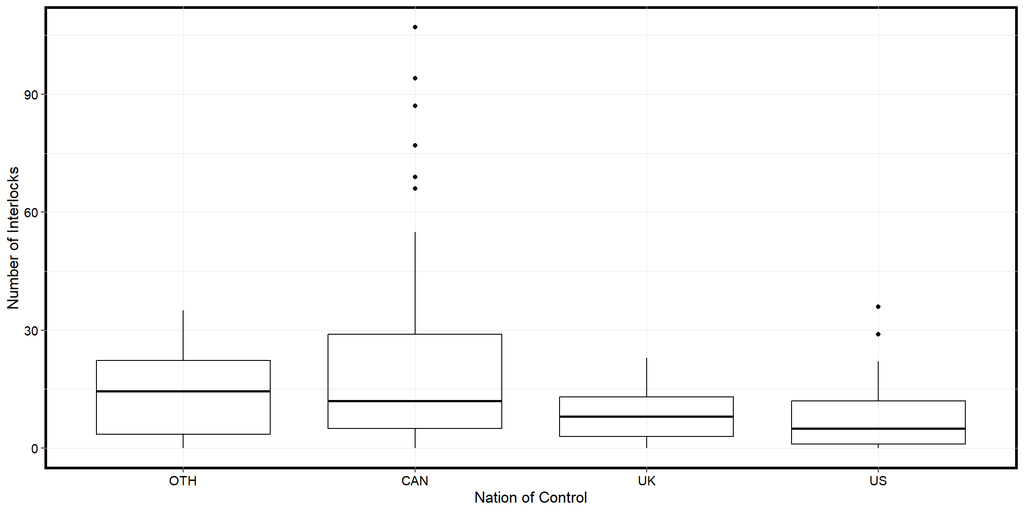

```r
data_path <- file.path(here(),
  "books",
  "Applied Regression Analysis and Generalized Linear Models",
  "data",
  "Ornstein.txt"
)
ornstein_dt <- data.table::fread(data_path) %>%
  .[, .(nation, interlocks)] %>%
  .[, nation := factor(nation)]

RplotterPkg::create_box_plot(
  df = ornstein_dt,
  aes_x = "nation",
  aes_y = "interlocks",
  order_by_median = "desc",
  x_title = "Nation of Control",
  y_title = "Number of Interlocks"
)
```

## 3.3 Plotting Multivariate Data

### 3.3.1 Scatterplot Matrices

Display a scatterplot matrix for occupational prestige, level of education, and level of income for 45 US occupations in 1950.

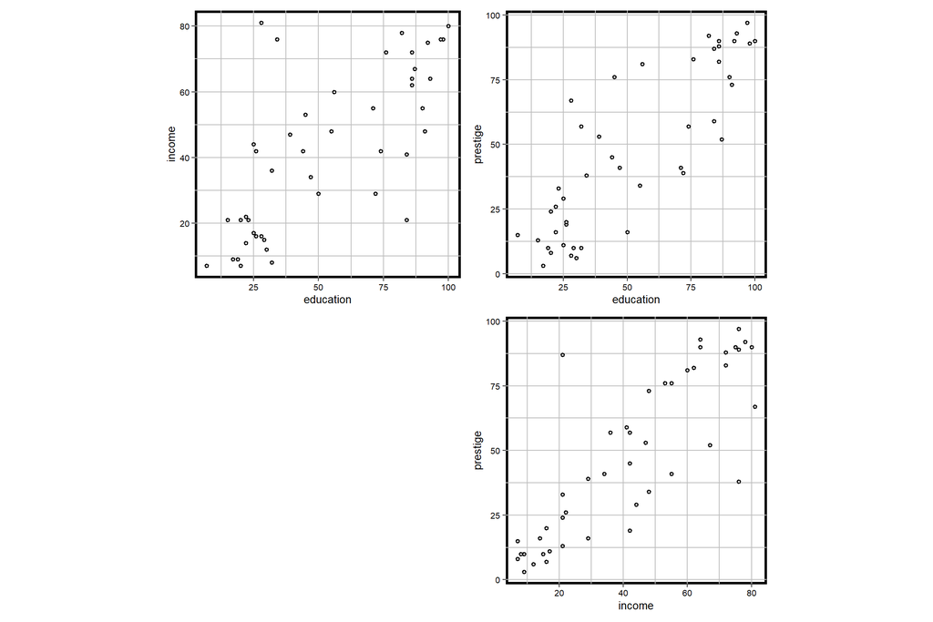

Scatterplot matrix for occupational prestige, level of education, and level of income

```r
data_path <- file.path(here(),
  "books",
  "Applied Regression Analysis and Generalized Linear Models",
  "data",
  "Duncan.txt"
)
duncan_dt <- data.table::fread(data_path) %>%
  .[, .(education, income, prestige)]

RregressPkg::plot_pairs(
  df = duncan_dt,
  var_name_scaling = list(
    education = NULL,
    income = NULL,
    prestige = NULL
  ),
  rot_y_tic_label = T,
  plot_dim = 20,
  axis_text_sz = 8
)
```